# 10486 - Analyze capture-mark-recapture data using *mrmr*

## Fit model

Code assumes that there are 8 physical cores available. Update parallel_chains and threads_per_chain as necessary based on actual number of cores. Add “control = list(adapt_delta = 0.99)” or similar if divergent transitions occur.

```r
model_10486 <- fit_model(
                    data = data_10486,
                    chains = 4,
                    parallel_chains = 4,
                    cpp_options = list(stan_threads = TRUE),
                    threads_per_chain = 2)
```

[output not shown]

[output cut: 18 more lines]

[output not shown]

[output not shown]

[output not shown]

[output not shown]

[output not shown]

[output not shown]

[output not shown]

[output not shown]

[output not shown]

[output not shown]

[output not shown]

[output not shown]

[output not shown]

[output not shown]

[output not shown]

[output not shown]

[output not shown]

[output not shown]

[output not shown]

[output not shown]

[output not shown]

[output not shown]

[output not shown]

[output not shown]

[output not shown]

[output not shown]

[output not shown]

[output not shown]

[output not shown]

[output not shown]

[output not shown]

[output not shown]

[output not shown]

[output not shown]

[output not shown]

[output not shown]

[output not shown]

[output not shown]

[output not shown]

[output not shown]

[output not shown]

[output not shown]

[output not shown]

[output not shown]

[output not shown]

[output not shown]

[output not shown]

[output not shown]

[output not shown]

[output not shown]

[output not shown]

[output not shown]

[output not shown]

[output not shown]

[output not shown]

[output not shown]

[output not shown]

[output not shown]

[output not shown]

[output not shown]

[output not shown]

[output not shown]

[output not shown]

[output not shown]

[output not shown]

[output not shown]

[output not shown]

[output not shown]

[output not shown]

[output not shown]

[output not shown]

[output not shown]

[output not shown]

[output not shown]

[output not shown]

[output not shown]

[output not shown]

[output not shown]

[output not shown]

[output not shown]

[output not shown]

[output not shown]

[output not shown]

[output not shown]

[output not shown]

[output not shown]

[output not shown]

[output not shown]

[output not shown]

[output not shown]

[output not shown]

[output not shown]

[output not shown]

[output not shown]

[output not shown]

[output not shown]

[output not shown]

[output not shown]

[output not shown]

[output not shown]

[output cut: 245 more lines]

[output not shown]

[output not shown]

[output not shown]

[output not shown]

[output not shown]

[output not shown]

[output not shown]

[output not shown]

[output not shown]

[output not shown]

[output not shown]

[output cut: 95 more lines]

[output not shown]

```
Running MCMC with 4 parallel chains, with 2 thread(s) per chain...

Chain 1 Iteration:    1 / 2000 [  0%]  (Warmup)
```

[output not shown]

```
Chain 2 Iteration:    1 / 2000 [  0%]  (Warmup)
Chain 3 Iteration:    1 / 2000 [  0%]  (Warmup)
```

[output not shown]

```
Chain 4 Iteration:    1 / 2000 [  0%]  (Warmup)
```

[output not shown]

[output not shown]

[output cut: 37 more lines]

```
Chain 2 Iteration: 1900 / 2000 [ 95%]  (Sampling)
Chain 4 Iteration: 1800 / 2000 [ 90%]  (Sampling)
Chain 3 Iteration: 2000 / 2000 [100%]  (Sampling)
Chain 3 finished in 24.0 seconds.
Chain 1 Iteration: 2000 / 2000 [100%]  (Sampling)
Chain 1 finished in 24.7 seconds.
Chain 2 Iteration: 2000 / 2000 [100%]  (Sampling)
Chain 4 Iteration: 1900 / 2000 [ 95%]  (Sampling)
Chain 2 finished in 25.1 seconds.
Chain 4 Iteration: 2000 / 2000 [100%]  (Sampling)
Chain 4 finished in 26.3 seconds.

All 4 chains finished successfully.
Mean chain execution time: 25.0 seconds.
Total execution time: 26.4 seconds.
```

- Running model with default adapt_delta (0.8) resulted in zero divergent transition (0/4000).

### Save/retrieve model object

This step prevents having to rerun the model in the event of a crash during model visualizations in subsequent code blocks. Model files can be large, so this saves the file in a compressed format.

```r
write_rds(model_10486, here::here("out", "model", "10486_model.rds"), "xz", compression = 9L)
```

```r
# model_10486 <- read_rds(here::here("out", "model", "10486_model.rds"))
```

### Diagnose potential non-convergence of the MCMC algorithm

Inspect traceplots and parameter summary table. In table, are any R<sub>hat</sub> values $\ge 1.01$?

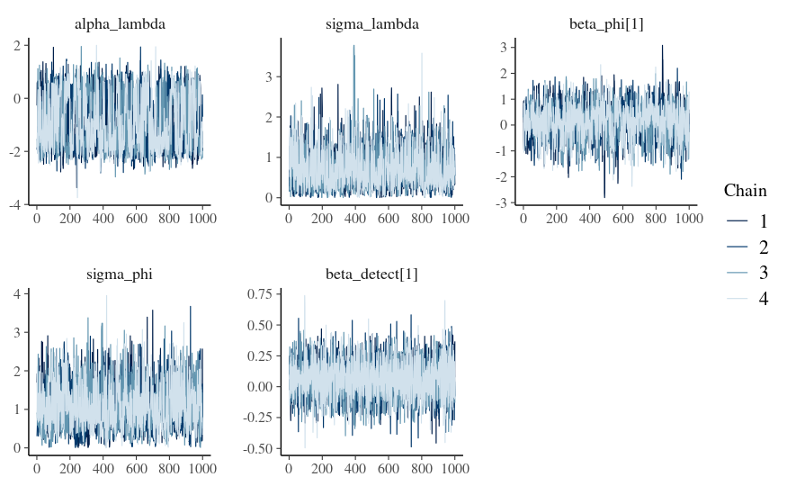

```r
pars_to_plot <- c('alpha_lambda',
                  'sigma_lambda',
                  'beta_phi',
                  'sigma_phi',
                  'beta_detect')
bayesplot::mcmc_trace(model_10486$m_fit$draws(pars_to_plot))
```

```r
model_10486$m_fit$summary(pars_to_plot)
```

| variable | mean | median | sd | mad | q5 | q95 | rhat | ess_bulk | ess_tail |
| --- | --- | --- | --- | --- | --- | --- | --- | --- | --- |
| alpha_lambda | -0.91342664 | -1.21567000 | 1.0382966 | 1.1341883 | -2.20658700 | 0.7788215 | 1.000863 | 612.1230 | 2007.348 |
| sigma_lambda | 0.70265825 | 0.60993250 | 0.4810201 | 0.4323440 | 0.09536774 | 1.5952790 | 1.000882 | 1610.0048 | 1564.773 |
| beta_phi[1] | 0.13780237 | 0.18755800 | 0.6518234 | 0.6022729 | -0.98509280 | 1.1538020 | 1.001346 | 1153.6810 | 2120.797 |
| sigma_phi | 1.07387286 | 1.00253500 | 0.5875181 | 0.5830695 | 0.23168175 | 2.1303925 | 1.000481 | 887.7376 | 1054.552 |
| beta_detect[1] | 0.06302425 | 0.06266945 | 0.1536015 | 0.1527510 | -0.18772095 | 0.3162053 | 1.001256 | 4038.2861 | 2497.248 |

## Visualize model results

### Default plots

Note: Custom plots (produced in next code chunk: “plots_custom”) are often easier to interpret than the default plots produced by this code chunk.

```r
# plot_model(model_10486, what = "abundance")
# plot_model(model_10486, what = "recruitment")
# plot_model(model_10486, what = "survival")
```

### Customize plots

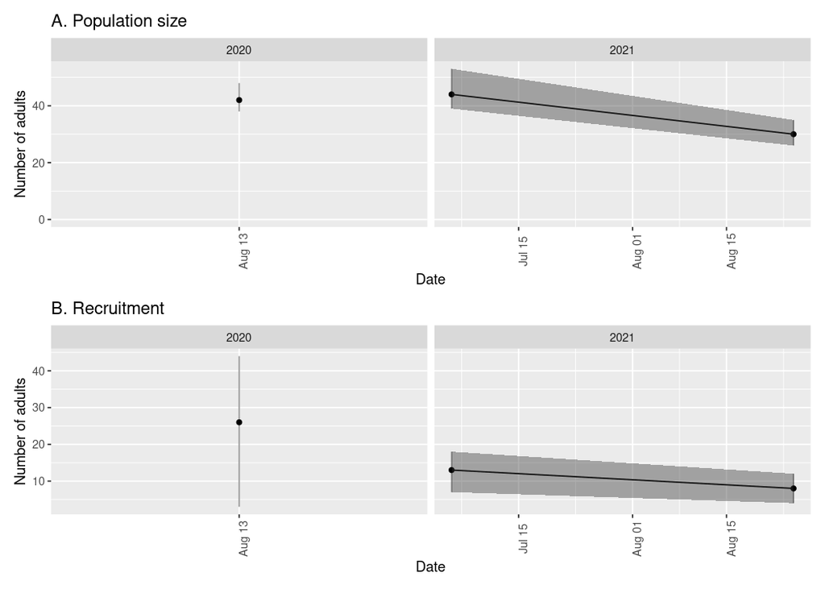

```r
library(ggplot2)
p1 <- plot_model(model_10486, what = "abundance")
p1 <- p1 + ggtitle("A. Population size") +
    ylab("Number of adults") +
    expand_limits(y = 0)

p2 <- plot_model(model_10486, what = "recruitment")
p2 <- p2 + ggtitle("B. Recruitment") +
    ylab("Number of adults")

p1 / p2
```

### Save custom plots

```r
ggsave(here::here("out", "plots", "10486_mrmr_plots.png"), width = 6.5, height = 4.8)
```